# Black Swan Bets

- Show All Code
- Hide All Code
- View Source

← Back to Home

# Portfolio Strategy: Convexity or Concavity?

|  | Convex Function | Concave Function |
| --- | --- | --- |
| Example | $f(x) = x^2$ | $f(x) = \sqrt{x}$ |
| Curve shape | Bends **upward** | Bends **downward** |
| Chord position | Lies **above** the curve | Lies **below** the curve |
| Financial intuition | Increasing gains in extremes | Diminishing returns |

When building a portfolio, investors often gravitate toward strategies that produce smooth, stable returns. These are typically based on concave payoffs — they perform reliably during normal market conditions but are vulnerable to extreme shocks. Think of strategies like shorting volatility or yield harvesting: small profits accumulate steadily, month after month — until a market dislocation triggers a sudden and devastating loss.

In contrast, convex strategies do the opposite. They accept small, repeated losses in exchange for the possibility of outsized gains during rare events. A classic example is buying out-of-the-money options: you lose the option premium most of the time, but if a crash (or boom) occurs, the payoff can be explosive. [Taleb’s “Black Swan” approach](https://www.penguin.co.uk/books/56147/fooled-by-randomness-by-taleb-nassim-nicholas/9780141031484) advocates precisely this — positioning a small part of the portfolio for tail events, while keeping the rest relatively safe.

|  | Markowitz ([Finance 101](https://math.nyu.edu/~goodman/teaching/RPME/notes/Section1.pdf)) | Taleb (Black Swan) |
| --- | --- | --- |
| Optimisation objective | Max mean return, given variance | Maximise convexity of tail payoff |
| Assumptions | Normal returns, iid shocks | Fat tails, rare shocks dominate |
| Mathematical nature | Concave utility, linear returns | Convex payoff, nonlinear returns |
| Payoff shape | Smooth, stable | Flat then explosive (e.g. options) |
| Exposure to tail risk | Minimised via diversification | Exploited as a source of asymmetry |
| Black Swans result | Vulnerable | Resilient or super-profitable |

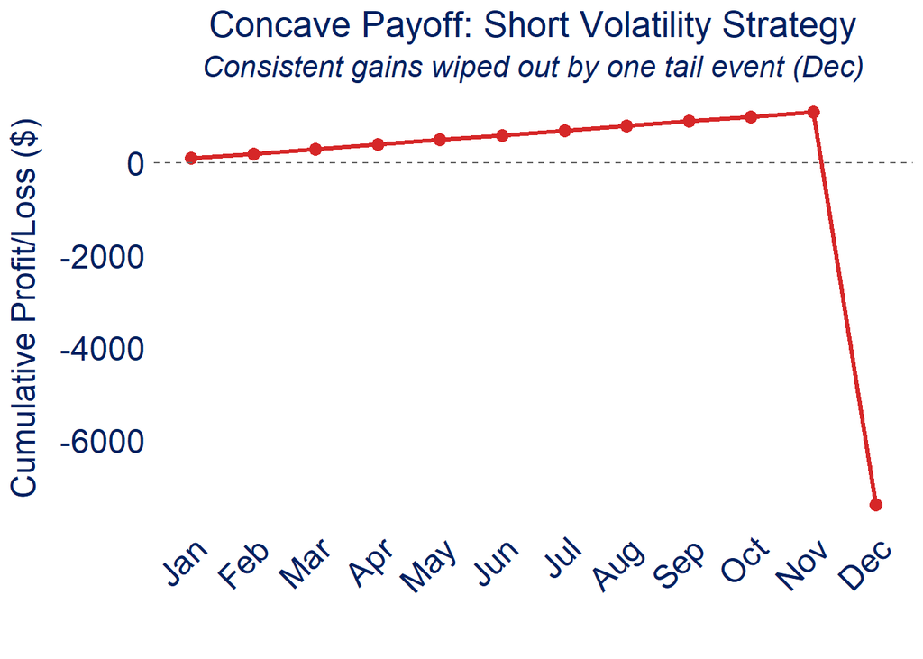

```r
# Concavity
monthly_pl <- c(rep(100, 11), -8500)
months <- month.abb[1:12]  # Jan to Dec

df <- data.frame(
  Month = factor(months, levels = months),
  Monthly_PL = monthly_pl) %>%
  mutate(Cumulative_PL = cumsum(Monthly_PL))

ggplot(df, aes(x = Month, y = Cumulative_PL, group = 1)) +
  geom_line(linewidth = 1.2, color = "#d62728") +
  geom_point(size = 3, color = "#d62728") +
  geom_hline(yintercept = 0, linetype = "dashed", color = "gray40") +
  labs(
    title = "Concave Payoff: Short Volatility Strategy",
    subtitle = "Consistent gains wiped out by one tail event (Dec)",
    x = "",
    y = "Cumulative Profit/Loss ($)") +
  theme_sph()
```

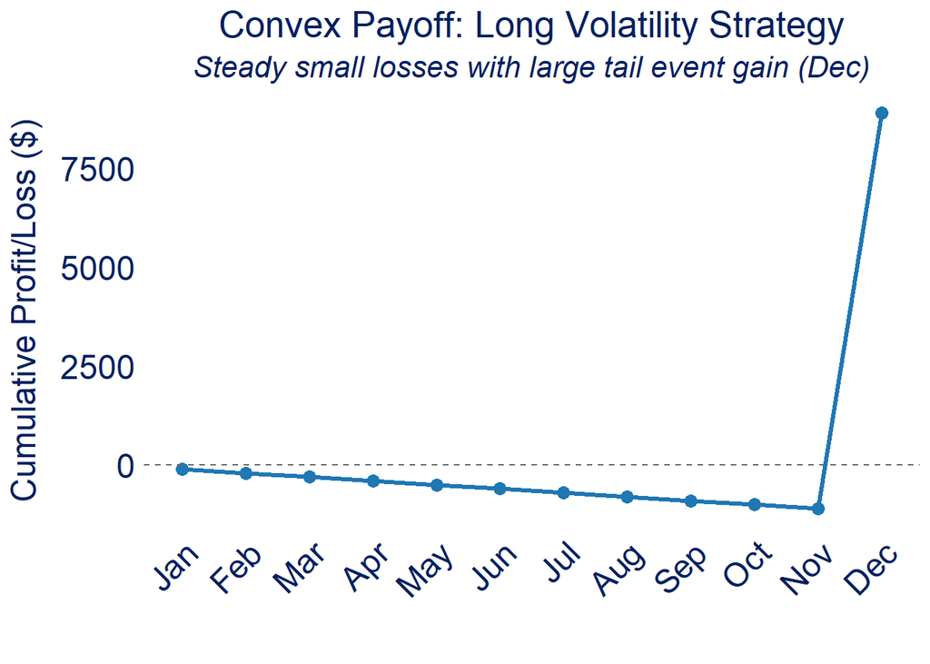

```r
# Convexity
monthly_pl_convex <- c(rep(-100, 11), 10000)
months <- month.abb[1:12]  # Jan to Dec

df_convex <- data.frame(
  Month = factor(months, levels = months),
  Monthly_PL = monthly_pl_convex) %>%
  mutate(Cumulative_PL = cumsum(Monthly_PL))

ggplot(df_convex, aes(x = Month, y = Cumulative_PL, group = 1)) +
  geom_line(linewidth = 1.2, color = "#1f77b4") +
  geom_point(size = 3, color = "#1f77b4") +
  geom_hline(yintercept = 0, linetype = "dashed", color = "gray40") +
  labs(
    title = "Convex Payoff: Long Volatility Strategy",
    subtitle = "Steady small losses with large tail event gain (Dec)",
    x = "",
    y = "Cumulative Profit/Loss ($)") +
  theme_sph()
```

Both strategies — concave and convex — have their place. But which is “better” depends on your goal: do you want to look smart most of the time (concave), or be right when it matters most (convex)? There is no right answer; you pays your money and you takes your choice.

# Is Diversification Overbought?

Finance 101 typically favours playing it safe. Diversification spreads risk and reduces volatility, and is widely regarded as a sensible, professional approach. But diversification also smooths out extremes. It dilutes the impact of tail opportunities as much as it protects against tail risks. For those wanting convex payoffs — seeking to profit from rare, asymmetric outcomes — diversification is not the way. Often diversification is just a cover; avoiding rather than managing risk head on.

*Behold, the fool saith, “Put not all thine eggs in the one basket” - which is but a manner of saying, “Scatter your money and your attention”; but the wise man saith, “Put all your eggs in the one basket and - WATCH THAT BASKET”* Quoted from Pudd’nhead Wilson, an 1894 novel by Mark Twain

There are clear parallels with the Fantasy Premier League game — one of my favourite pastimes. As a manager, playing it safe — picking the most-owned captain, spreading the risk across consistent, high-ownership players — might keep you comfortably mid-table. But you won’t reach elite status by following the crowd. The aim isn’t to average 60 points a week. Fantasy success, like portfolio convexity, is about capturing upside — grabbing that one-week megahaul when your triple-captained differential bags a hat-trick. Hedging and diversifying might be wise if you’re managing your Nan’s pension. But in Fantasy, as in certain investment strategies, the lodestar is glory — not mere survival.